# BIOSTAT 620 HW 2

Author

Kyoka Ono

## Data Wrangling

- Individual data: includes personal and health characteristics of children in 12 communities across Southern California.
- Regional data: include air quality measurements at the community level.

```r
library(tidyverse)
library(data.table)
library(ggplot2)
library(leaflet)
library(corrplot)
```

```r
url_ind <- "https://raw.githubusercontent.com/dmcable/BIOSTAT620W26/main/data/chs/chs_individual.csv"
individual <- read.csv(url_ind)
```

```r
url_regi <- "https://raw.githubusercontent.com/dmcable/BIOSTAT620W26/main/data/chs/chs_regional.csv"
regional <- read.csv(url_regi)
```

### Question 1

- Merge datasets using the “location” variable
- Make sure you don’t have any duplicates by counting the number of rows
- Impute data using the average amongst individuals with the same values for the “male” and “hispanic” variables.
- For categorical variables, take the mode.

```r
# merge data using "townname" variable
data_merged <- merge(
  x = individual,
  y = regional,
  by.x = "townname",
  by.y = "townname",
  all.x = TRUE,
  all.y = FALSE
)
```

```r
# Check which column contains NAs
na_vec <- c()
for (i in colnames(data_merged))
{
  if (sum(is.na(data_merged[i])) > 0){
    na_vec <- c(na_vec, i)
  }
}
na_vec
```

```
 [1] "agepft"        "height"        "weight"        "bmi"
 [5] "asthma"        "father_asthma" "mother_asthma" "wheeze"
 [9] "hayfever"      "allergy"       "educ_parent"   "smoke"
[13] "gasstove"      "fev"           "fvc"           "mmef"
[17] "no_24hr"       "pm2_5_fr"
```

```r
str(data_merged[na_vec])
```

```
'data.frame':   1200 obs. of  18 variables:
 $ agepft       : num  10.55 10.1 9.49 9.97 10.04 ...
 $ height       : int  150 143 133 146 162 141 139 142 143 137 ...
 $ weight       : int  78 69 62 78 140 94 65 86 65 69 ...
 $ bmi          : num  15.8 15.3 15.9 16.6 24.2 ...
 $ asthma       : int  0 0 0 0 1 0 0 0 NA 0 ...
 $ father_asthma: int  0 0 0 0 0 NA 0 0 NA 0 ...
 $ mother_asthma: int  0 0 0 0 0 0 0 1 NA 0 ...
 $ wheeze       : int  0 0 0 0 1 0 1 1 NA 0 ...
 $ hayfever     : int  0 0 0 0 0 0 0 1 NA 0 ...
 $ allergy      : int  0 1 0 0 1 0 0 1 NA 0 ...
 $ educ_parent  : int  5 3 4 NA 3 5 1 3 NA 5 ...
 $ smoke        : int  0 0 NA NA 0 0 1 1 NA 0 ...
 $ gasstove     : int  0 0 0 NA 1 1 0 0 NA 1 ...
 $ fev          : num  2252 2529 1738 2467 2584 ...
 $ fvc          : num  2595 2826 1964 2638 3568 ...
 $ mmef         : num  2445 3407 2133 3466 2071 ...
 $ no_24hr      : num  2.48 2.48 2.48 2.48 2.48 2.48 2.48 2.48 2.48 2.48 ...
 $ pm2_5_fr     : num  10.3 10.3 10.3 10.3 10.3 ...
```

```r
continuous_binary_na_data <- c("agepft",
             "height",
             "weight",
             "bmi",
             "fev",
             "fvc",
             "mmef",
             "no_24hr",
             "pm2_5_fr")

gend_hispanic_data <- data_merged[c("male","hispanic")]

for (i in continuous_binary_na_data){

  column_data_cont <- data_merged[[i]]
  na_ind <- which(is.na(column_data_cont))

  gender_data <- gend_hispanic_data[[1]]
  hispanic_data <- gend_hispanic_data[[2]]

  gend_0_hisp_0_ind <- which(gender_data == 0 & hispanic_data == 0)
  gend_1_hisp_1_ind <- which(gender_data == 1 & hispanic_data == 1)
  gend_0_hisp_1_ind <- which(gender_data == 0 & hispanic_data == 1)
  gend_1_hisp_0_ind <- which(gender_data == 1 & hispanic_data == 0)

  gend_0_hisp_0_avg <- mean(column_data_cont[gend_0_hisp_0_ind], na.rm = TRUE)
  gend_1_hisp_1_avg <- mean(column_data_cont[gend_1_hisp_1_ind], na.rm = TRUE)
  gend_0_hisp_1_avg <- mean(column_data_cont[gend_0_hisp_1_ind], na.rm = TRUE)
  gend_1_hisp_0_avg <- mean(column_data_cont[gend_1_hisp_0_ind], na.rm = TRUE)

  for (j in na_ind){

    male_ind_val <- data_merged$male[j]
    hisp_ind_val <- data_merged$hispanic[j]

    if (male_ind_val == 0 & hisp_ind_val == 0){

      column_data_cont[j] <- gend_0_hisp_0_avg  # data imputation

    }else if(male_ind_val == 1 & hisp_ind_val == 1){

      column_data_cont[j] <- gend_1_hisp_1_avg # data imputation

    }else if(male_ind_val == 0 & hisp_ind_val == 1){

      column_data_cont[j] <- gend_0_hisp_1_avg # data imputation

    }else if(male_ind_val == 1 & hisp_ind_val == 0){

      column_data_cont[j] <- gend_1_hisp_0_avg # data imputation
    }
  }
  data_merged[[i]] <- column_data_cont
}
```

```r
categorical_na_data <- c("educ_parent",
                         "asthma",
                         "father_asthma",
                         "mother_asthma",
                         "wheeze",
                         "hayfever",
                         "allergy",
                         "smoke",
                         "gasstove")

for (i in categorical_na_data){
  column_data_cat <- data_merged[i]
  mode <- names(sort(table(column_data_cat), decreasing = TRUE))[1]
  column_data_cat[is.na(column_data_cat)] <- mode
  data_merged[i] <- column_data_cat
}
```

```r
# making sure all the NA data are replaced
sum(is.na(data_merged))
```

```
[1] 0
```

### Question 2

Create a new categorical variable named “obesity_level” using the BMI measurement (underweight BMI < 14; normal 14-22; overweight BMI 22-24; obese BMI > 24).

To make sure the variable is rightly coded, create a summary table that contains the minimum BMI, maximum BMI, and the total number of observations per category.

```r
data_merged <- data_merged %>%
  mutate(obesity_level = fifelse(bmi < 14, "underweight",
                                 fifelse(bmi >= 14 & bmi < 22, "normal",
                                         fifelse(bmi >= 22 & bmi < 24, "overweight", "obese"))))
```

```r
max(data_merged$bmi[which(data_merged$obesity_level == "underweight")])
```

```
[1] 13.98601
```

```r
min(data_merged$bmi[which(data_merged$obesity_level == "underweight")])
```

```
[1] 11.2964
```

```r
max(data_merged$bmi[which(data_merged$obesity_level == "normal")])
```

```
[1] 21.96387
```

```r
min(data_merged$bmi[which(data_merged$obesity_level == "normal")])
```

```
[1] 14.0038
```

```r
max(data_merged$bmi[which(data_merged$obesity_level == "overweight")])
```

```
[1] 23.9965
```

```r
min(data_merged$bmi[which(data_merged$obesity_level == "overweight")])
```

```
[1] 22.02353
```

```r
max(data_merged$bmi[which(data_merged$obesity_level == "obese")])
```

```
[1] 41.26613
```

```r
min(data_merged$bmi[which(data_merged$obesity_level == "obese")])
```

```
[1] 24.00647
```

```r
table(data_merged$obesity_level)
```

```
     normal       obese  overweight underweight
        975         103          87          35
```

```r
# make obesity_level as factor
data_merged$obesity_level <- factor(data_merged$obesity_level)
```

### Question 3

Create another categorical variable named “smoke_gas_exposure” that summarizes “Second Hand Smoke” and “Gas Stove.” The variable should have four categories in total.

1. Second Hand Smoke = 0 & Gas Stove = 0: No Exposure
2. Second Hand Smoke = 1 & Gas Stove = 1: Both
3. Second Hand Smoke = 0 & Gas Stove = 1: GS Only
4. Second Hand Smoke = 1 & Gas Stove = 0: SHS Only

```r
data_merged <- data_merged %>%
  mutate(smoke_gas_exposure = fifelse(smoke == 0 & gasstove == 0, "No Exposure",
                                 fifelse(smoke == 1 & gasstove == 1, "Both",
                                         fifelse(smoke == 0 & gasstove == 1, "GS Only", "SHS Only"))))
```

```r
# make smoke_gas_exposure as factor
data_merged$smoke_gas_exposure <- factor(data_merged$smoke_gas_exposure)
```

### Question 4

Create four summary tables showing the average (or proportion, if binary) and sd of “Forced expiratory volume in 1 second (ml)” (an asthma indicator) by town, sex, obesity_level, and smoke_gas_exposure. Comment on your findings.

```r
data_merged %>% group_by(townname) %>% summarize(fev_avg_by_town = mean(fev, na.rm = TRUE),
                                                 fev_sd_by_town = sd(fev, na.rm = TRUE))
```

```
# A tibble: 12 × 3
   townname      fev_avg_by_town fev_sd_by_town
   <chr>                   <dbl>          <dbl>
 1 Alpine                  2087.           291.
 2 Atascadero              2076.           324.
 3 Lake Elsinore           2039.           304.
 4 Lake Gregory            2085.           320.
 5 Lancaster               2003.           317.
 6 Lompoc                  2034.           351.
 7 Long Beach              1986.           319.
 8 Mira Loma               1985.           325.
 9 Riverside               1990.           278.
10 San Dimas               2027.           319.
11 Santa Maria             2026.           312.
12 Upland                  2024.           343.
```

```r
data_merged %>% group_by(male) %>% summarize(fev_avg_by_gender = mean(fev, na.rm = TRUE),
                                             fev_sd_by_gender = sd(fev, na.rm = TRUE)) %>% arrange(fev_avg_by_gender )
```

```
# A tibble: 2 × 3
   male fev_avg_by_gender fev_sd_by_gender
  <int>             <dbl>            <dbl>
1     0             1959.             312.
2     1             2104.             308.
```

```r
data_merged %>% group_by(obesity_level) %>% summarize(fev_avg_by_obesity_level = mean(fev, na.rm = TRUE),
                                                      fev_sd_by_obesity_level = sd(fev, na.rm = TRUE)) %>% arrange(fev_avg_by_obesity_level)
```

```
# A tibble: 4 × 3
  obesity_level fev_avg_by_obesity_level fev_sd_by_obesity_level
  <fct>                            <dbl>                   <dbl>
1 underweight                      1698.                    303.
2 normal                           2000.                    295.
3 overweight                       2224.                    317.
4 obese                            2266.                    325.
```

Looking at the average fev among different weight groups, there is an increase in fev average as the bmi/weights increase.

```r
data_merged %>% group_by(smoke_gas_exposure) %>% summarize(fev_avg_by_smoke_gas_exp = mean(fev, na.rm = TRUE),
                                                           fev_sd_by_smoke_gas_exp = sd(fev, na.rm = TRUE)) %>% arrange(fev_avg_by_smoke_gas_exp)
```

```
# A tibble: 4 × 3
  smoke_gas_exposure fev_avg_by_smoke_gas_exp fev_sd_by_smoke_gas_exp
  <fct>                                 <dbl>                   <dbl>
1 GS Only                               2023.                    319.
2 Both                                  2025.                    301.
3 SHS Only                              2056.                    296.
4 No Exposure                           2057.                    329.
```

### Looking at the Data (EDA)

The primary questions of interest are:

1. What is the association between BMI and FEV (forced expiratory volume)?
2. What is the association between smoke and gas exposure and FEV?
3. What is the association between PM2.5 exposure and FEV?

Follow the EDA checklist from week 3 and the previous assignment. Be sure to focus on the key variables. Hint: the variable for total PM2.5 is pm25_mass.

EDA Checklist: 1. Read in the data (already done) 2. Check the size of the data

```r
dim(data_merged)
```

```
[1] 1200   51
```

3. Examine the variables and their types

```r
str(data_merged$bmi)
```

```
 num [1:1200] 15.8 15.3 15.9 16.6 24.2 ...
```

```r
str(data_merged$smoke_gas_exposure)
```

```
 Factor w/ 4 levels "Both","GS Only",..: 3 3 3 2 2 2 4 4 2 2 ...
```

```r
str(data_merged$fev)
```

```
 num [1:1200] 2252 2529 1738 2467 2584 ...
```

```r
str(data_merged$pm25_mass)
```

```
 num [1:1200] 8.74 8.74 8.74 8.74 8.74 8.74 8.74 8.74 8.74 8.74 ...
```

4. Look at the top and bottom of the data

```r
head(data_merged)
```

```
  townname sid male race hispanic    agepft height weight      bmi asthma
1   Alpine 841    1    W        1 10.548939    150     78 15.75758      0
2   Alpine 835    0    W        0 10.099932    143     69 15.33749      0
3   Alpine 838    0    O        1  9.486653    133     62 15.93183      0
4   Alpine 840    0    W        0  9.965777    146     78 16.63283      0
5   Alpine 865    0    W        0 10.039699    162    140 24.24797      1
6   Alpine 867    0    W        1  9.957563    141     94 21.49151      0
  active_asthma father_asthma mother_asthma wheeze hayfever allergy educ_parent
1             0             0             0      0        0       0           5
2             0             0             0      0        0       1           3
3             0             0             0      0        0       0           4
4             0             0             0      0        0       0           3
5             1             0             0      1        0       1           3
6             0             0             0      0        0       0           5
  smoke pets gasstove      fev      fvc     mmef pm25_mass pm25_so4 pm25_no3
```

[output cut: 27 more lines]

```r
tail(data_merged)
```

```
     townname  sid male race hispanic    agepft  height   weight      bmi
1195   Upland 1866    0    O        1  9.806982 139.000 60.00000 14.11559
1196   Upland 1867    0    M        1  9.618070 140.000 71.00000 16.46568
1197   Upland 2033    0    M        0 10.121834 130.000 67.00000 18.02044
1198   Upland 2031    1    W        0  9.798768 135.000 83.00000 20.70084
1199   Upland 2032    1    W        0  9.549624 137.000 59.00000 14.28855
1200   Upland 2053    0    W        0  9.849789 138.972 77.39564 18.05281
     asthma active_asthma father_asthma mother_asthma wheeze hayfever allergy
1195      0             0             0             0      0        0       0
1196      0             0             1             0      0        0       0
1197      0             1             0             0      1        1       0
1198      0             0             0             0      1        0       1
1199      0             0             0             1      1        1       1
1200      0             0             0             0      0        0       0
     educ_parent smoke pets gasstove      fev      fvc     mmef pm25_mass
```

[output cut: 34 more lines]

5. Visualize the distributions of key variables

```r
summary(data_merged$bmi)
```

```
   Min. 1st Qu.  Median    Mean 3rd Qu.    Max.
  11.30   15.96   17.81   18.50   19.99   41.27
```

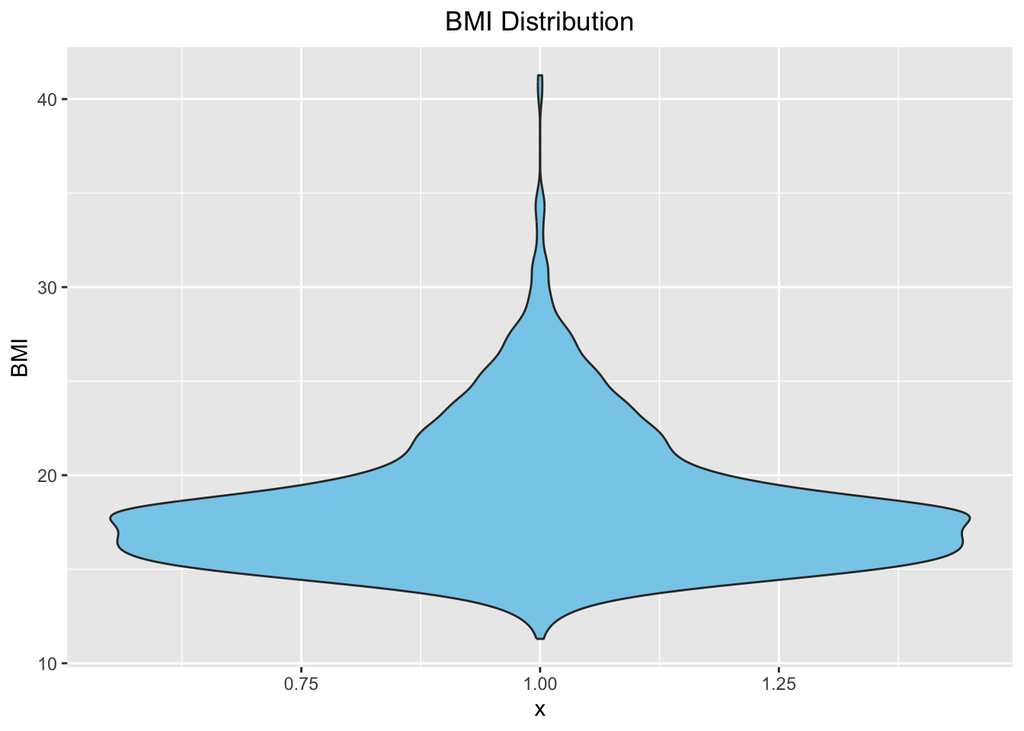

```r
ggplot(data = data_merged, aes(x = 1, y = bmi)) +
  geom_violin(fill = "skyblue") +
  labs(title = "BMI Distribution") +
  labs(y = "BMI") +
  theme(plot.title = element_text(hjust = 0.5))
```

(https://www.nhlbi.nih.gov/calculate-your-bmi#:~:text=Table_title:%20Weight%20Table_content:%20header:%20%7C%20BMI%20Category,%7C%20BMI%20Range:%2030.0%20or%20above%20%7C)

```r
summary(data_merged$fev)
```

```
   Min. 1st Qu.  Median    Mean 3rd Qu.    Max.
  984.8  1827.6  2016.4  2030.1  2223.6  3323.7
```

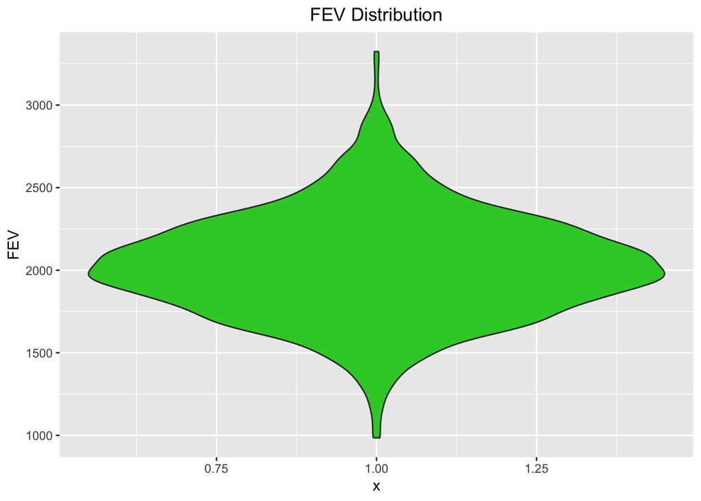

```r
ggplot(data = data_merged, aes(x = 1, y = fev)) +
  geom_violin(fill = "limegreen") +
  labs(title = "FEV Distribution") +
  labs(y = "FEV") +
  theme(plot.title = element_text(hjust = 0.5))
```

```r
table(data_merged$smoke_gas_exposure)
```

```
       Both     GS Only No Exposure    SHS Only
        154         791         219          36
```

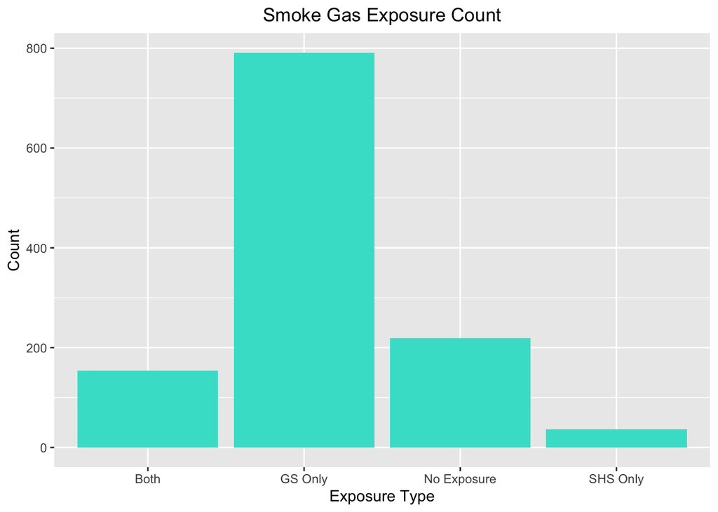

```r
ggplot(data = data_merged, aes(x = smoke_gas_exposure)) +
  geom_bar(fill = "turquoise") +
  labs(title = "Smoke Gas Exposure Count") +
  labs(x = "Exposure Type", y = "Count") +
  theme(plot.title = element_text(hjust = 0.5))
```

```r
summary(data_merged$pm25_mass)
```

```
   Min. 1st Qu.  Median    Mean 3rd Qu.    Max.
  5.960   7.615  10.545  14.362  20.988  29.970
```

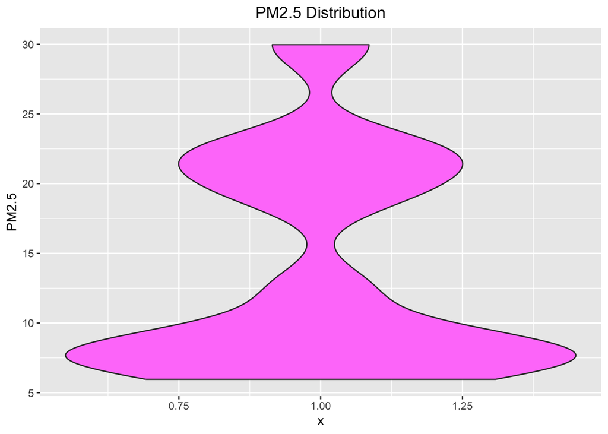

```r
ggplot(data = data_merged, aes(x = 1, y = pm25_mass)) +
  geom_violin(fill = "orchid1") +
  labs(title = "PM2.5 Distribution") +
  labs(y = "PM2.5") +
  theme(plot.title = element_text(hjust = 0.5))
```

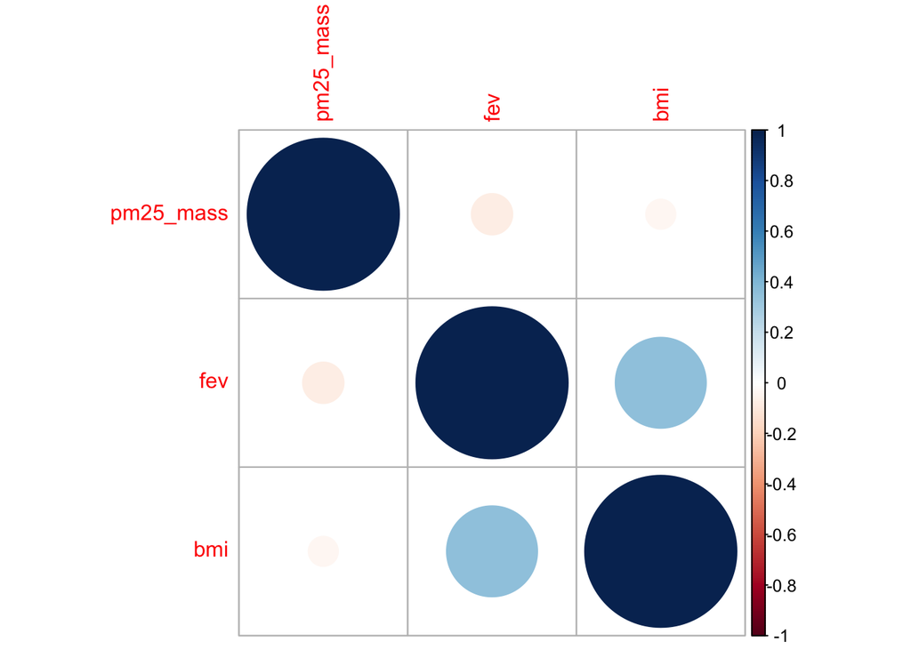

```r
correlation_data <- data_merged[c("pm25_mass", "fev", "bmi")]
corrplot(cor(correlation_data), method = "circle")
```

### Visualization

Create the following figures and interpret them. Be sure to include easily understandable axes, titles, and legends.

1. Facet plot showing scatterplots with regression lines of BMI vs FEV by “townname”.

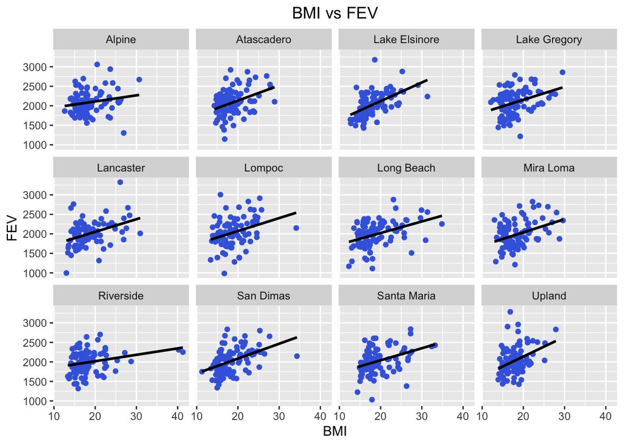

```r
ggplot(data = data_merged, aes(x = bmi, y = fev)) +
  geom_point(color = "royalblue") +
  geom_smooth(method = lm, se = FALSE, color = "black") +
  facet_wrap(~townname) +
  labs(title = "BMI vs FEV") +
  theme(plot.title = element_text(hjust = 0.5)) +
  labs(x = "BMI", y = "FEV")
```

As BMI increases, FEV increases as well. There is also a linear positive association between these two variables.

2. Stacked histograms of FEV by BMI category and FEV by smoke/gas exposure. Use different color schemes than the ggplot default.

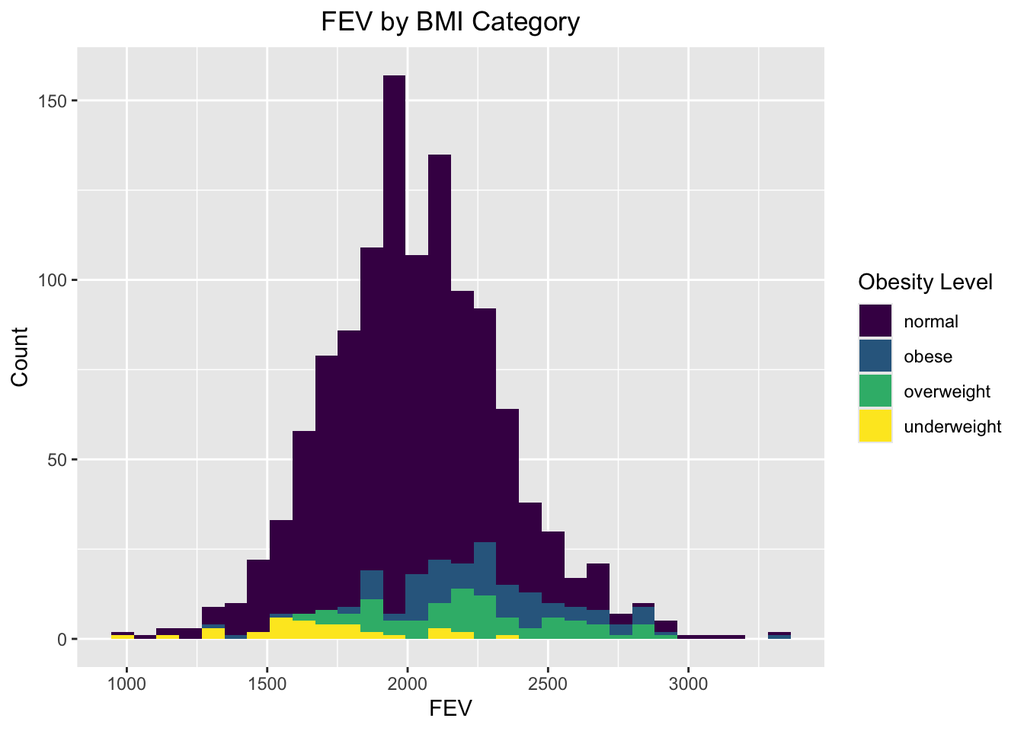

```r
ggplot(data = data_merged) +
  geom_histogram(mapping = aes(x = fev, fill = obesity_level)) +
  labs(title = "FEV by BMI Category") +
  labs(x = "FEV", y = "Count") +
  theme(plot.title = element_text(hjust = 0.5)) +
  labs(fill = "Obesity Level") +
  scale_fill_viridis_d()
```

According to the histogram visualization, this data is normally distributed. The most frequently appeared fev for people with normal obesity level is around 2000, 2250 for overweight people, 2300 for people who are in obese category, and approximately 1600 for people categorized as underweight.

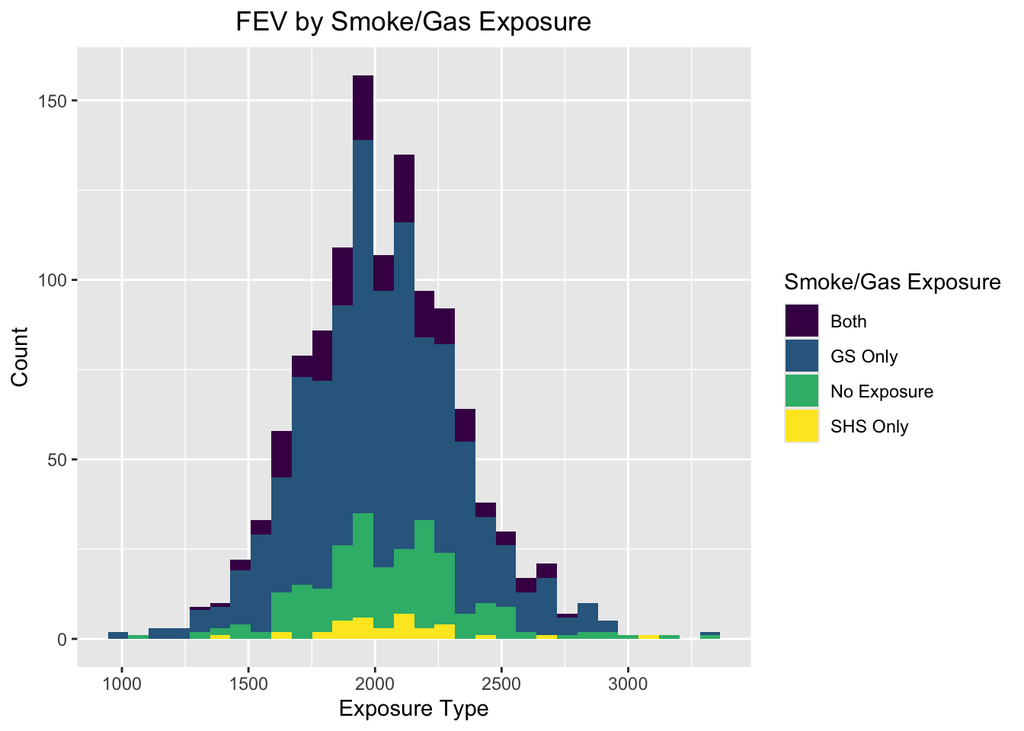

```r
ggplot(data = data_merged) +
  geom_histogram(mapping = aes(x = fev, fill = smoke_gas_exposure)) +
  labs(title = "FEV by Smoke/Gas Exposure") +
  labs(x = "Exposure Type", y = "Count") +
  theme(plot.title = element_text(hjust = 0.5)) +
  labs(fill = "Smoke/Gas Exposure") +
  scale_fill_viridis_d()
```

This data is normally distributed as well. The interpretation is similar to the histogram above. The most frequently appeared fev is similar for “Both” and “GS Only” groups, and higher for “No Exposure” and “SHS Only” groups.

3. Barchart of BMI by smoke/gas exposure

```r
bmi_avg_by_exposure <- data_merged %>% group_by(smoke_gas_exposure) %>% summarize(bmi_avg = mean(bmi))
bmi_avg_by_exposure
```

```
# A tibble: 4 × 2
  smoke_gas_exposure bmi_avg
  <fct>                <dbl>
1 Both                  19.1
2 GS Only               18.4
3 No Exposure           18.2
4 SHS Only              19.2
```

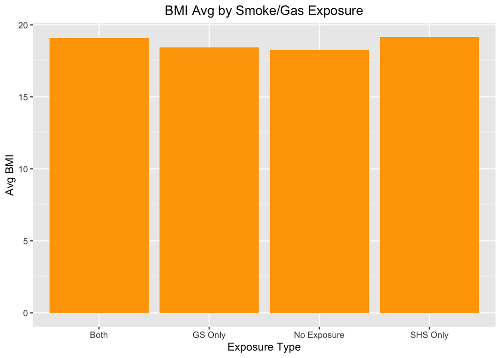

```r
ggplot(data = bmi_avg_by_exposure) +
  geom_col(mapping = aes(x = smoke_gas_exposure, y = bmi_avg), fill = "orange1") +
  labs(title = "BMI Avg by Smoke/Gas Exposure") +
  labs(x = "Exposure Type", y = "Avg BMI") +
  theme(plot.title = element_text(hjust = 0.5))
```

Average BMI is almost the same across all smoke/gas exposure categories. There does not seem to be a significant association between these two variables.

4. Statistical summary graphs of FEV by BMI and FEV by smoke/gas exposure category.

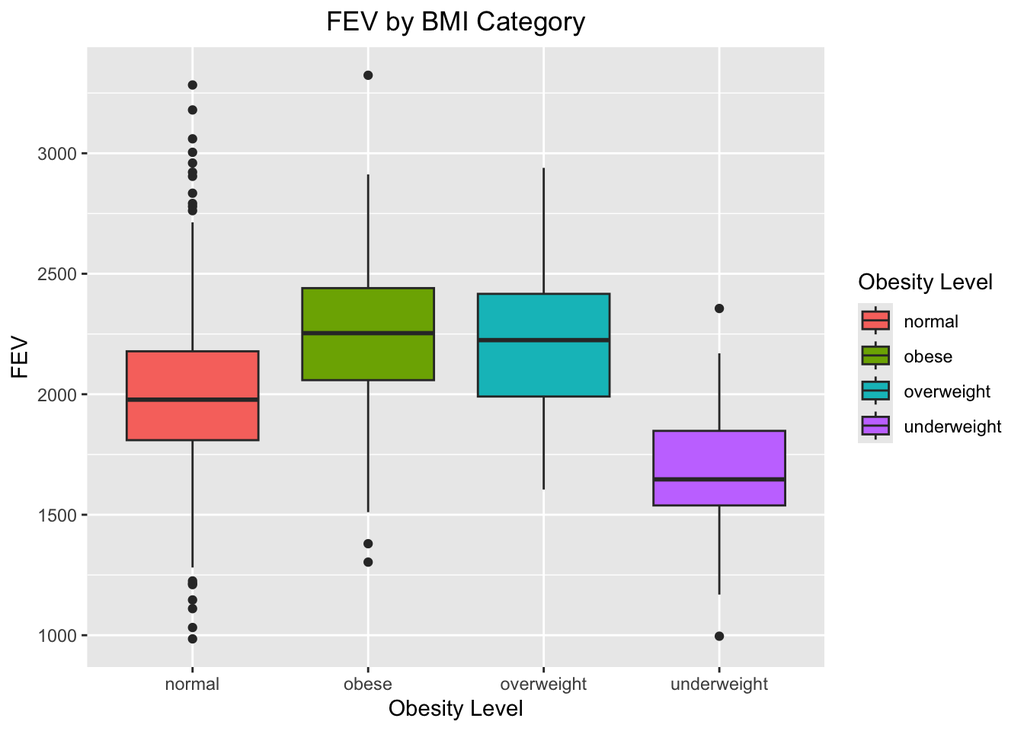

```r
ggplot(data = data_merged) +
  geom_boxplot(mapping = aes(x = obesity_level, y = fev, fill = obesity_level)) +
  labs(title = "FEV by BMI Category") +
  labs(x = "Obesity Level", y = "FEV") +
  theme(plot.title = element_text(hjust = 0.5)) +
  labs(fill = "Obesity Level")
```

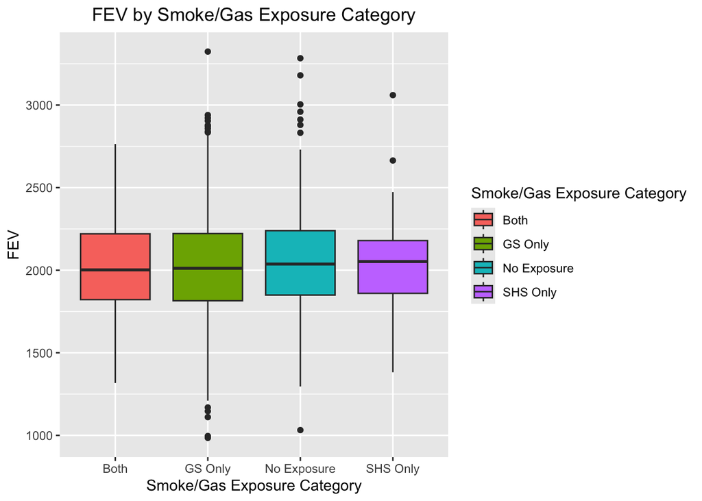

```r
ggplot(data = data_merged) +
  geom_boxplot(mapping = aes(x = smoke_gas_exposure, y = fev, fill = smoke_gas_exposure)) +
  labs(title = "FEV by Smoke/Gas Exposure Category") +
  labs(x = "Smoke/Gas Exposure Category", y = "FEV") +
  theme(plot.title = element_text(hjust = 0.5)) +
  labs(fill = "Smoke/Gas Exposure Category")
```

5. A leaflet map showing the concentrations of PM2.5 mass in each of the CHS communities.

```r
# Generating a color palette
pm_pal <- colorNumeric(c("darkgreen", "goldenrod", "brown", "red"), domain = data_merged$pm25_mass)

pm_map <- leaflet(data_merged) %>%
  addProviderTiles("CartoDB.Positron") %>%
  # Some circles
  addCircles(
    lat = ~lat, lng = ~lon,
    color = ~pm_pal(pm25_mass),
    opacity = 1, fillOpacity = 1, radius = 4000
  ) %>%
  # Add legend
  addLegend("bottomleft", pal = pm_pal, values = data_merged$pm25_mass, title = "PM2.5 Mass", opacity = 1)
```

```r
pm_map
```

[interactive chart not shown]

Towns that are close to Los Angeles have higher PM2.5, indicating that bigger cities are apt to have higher PM2.5 due to mass population.

6. Choose a visualization to examine whether PM2.5 mass is associated with FEV.

```r
# pm2.5 mass value is unique to each location
length(unique(data_merged$townname))
```

```
[1] 12
```

```r
length(unique(data_merged$pm25_mass))
```

```
[1] 12
```

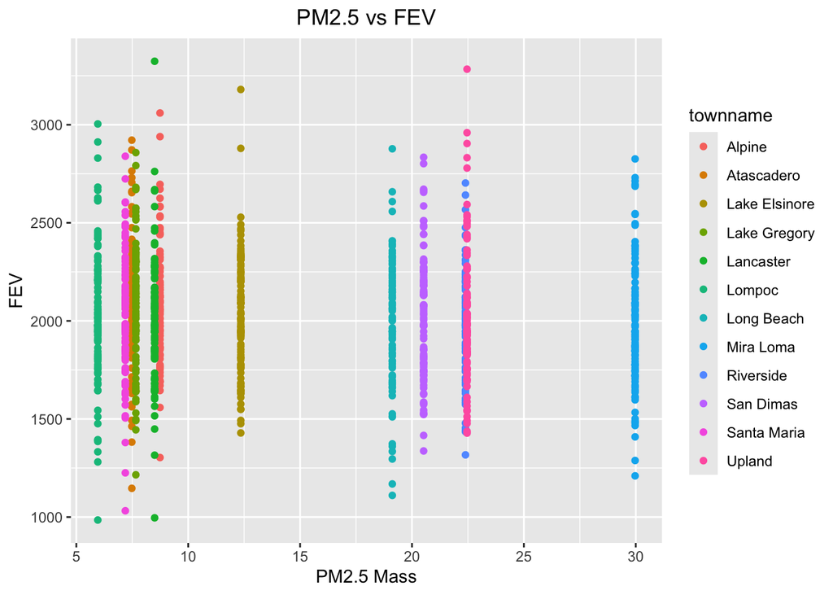

```r
ggplot(data = data_merged) +
  geom_point(aes(x = pm25_mass, y = fev, color = townname)) +
  labs(title = "PM2.5 vs FEV") +
  theme(plot.title = element_text(hjust = 0.5)) +
  labs(x = "PM2.5 Mass", y = "FEV")
```

There is no linear relationship between PM2.5 mass and FEV. There is no significant association between PM2.5 mass and FEV.